# The importance of active voice in your writing…

## Too many words

- **Our thoughts can be disorganized and tangled up. Particularly when worried about tackling an important assignment like the capstone paper**
- **This will inevitably lead to disorganized writing**
- **This disorganization almost always causes us to use too many words to say things**

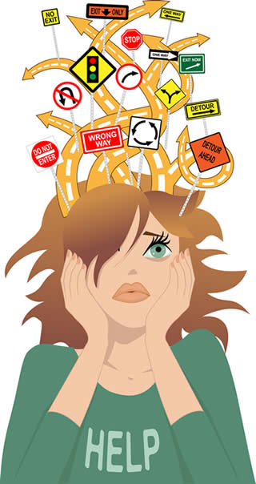

## Eliminate complicated words

- **One of the best ways to make your writing easier on readers is to eliminate complicated words**
- **While many people utilize big words to sound more sophisticated, you should use more common synonyms if they exist.**
  - Dr. C insists on the K.I.S.S principle
  - the goal is to share ideas, NOT impress

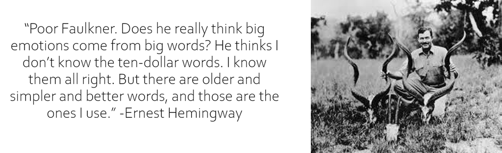

## Active voice vs. passive voice

- **In a sentence written in the active voice, the subject of sentence performs the action:**

**The candidate believes that Congress must place a ceiling on the budget.**  
12 words = :)

- **In a sentence written in the passive voice, the subject receives the action:**

**It is believed by the candidate that a ceiling must be placed on the budget by Congress.**  
17 words = :(

## Active voice vs. passive voice

- **Sentences in the passive voice tend to:**
  - Use more words
  - Cause a tangle of prepositional phrases (subject often buried next to ‘by’)
  - Confuse the reader by making things more complicated than necessary

Passive: **It has been demonstrated by researchers that heart attacks can be caused by high stress.**  
Active: **Researchers have demonstrated that high stress can cause heart attacks.**

Passive: **The man was bitten by the dog.**  
Active: **The dog bit the man.**

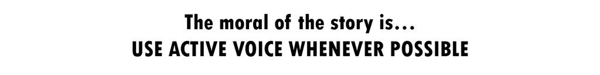

## Converting sentences to active voice

Passive: **It has been demonstrated by researchers that heart attacks can be caused by high stress.**

Active: **Researchers have demonstrated that high stress can cause heart attacks.**

- **Some tips and strategies for converting sentences from the passive to the active voice:**
  - Look for a “by” phrase (e.g., “by the dog” in the previous slide). If you find one, the sentence may be in the passive voice
  - Rewrite the sentence so that a subject buried in the “by” clause is closer to the sentence beginning
  - If the subject of the sentence is not clear, see if you can use a general term, such as “researchers,” or “the study,” or “experts in this field.”
  - This sentence ‘flipping’ puts the subject first and often removes unnecessary words

## More Pro Tips for active voice

- **Swap ‘ing’ for ‘ed’. Words ending in ‘ing’ tend to be more passive than ‘ed’**
- **Go easy on the adverbs. Although it may be more descriptive, too many adverbs slow down your writing and interrupts the flow.**
  - If your verb isn’t strong enough (meaning you need to add adverbs), consider changing it.
- **Don’t be afraid to add the ‘person’ into your writing. Science writing is changing! It is now more accepted to write in the first person (e.g., we found…, our results show…).**
  - Using the first person humanizes your work and makes it more enjoyable to read for a broader audience.

## Pro Tips: Write with the reader in mind

- **Readers do not simply read; they interpret. Any piece of writing, no matter how short, may mean different things to different readers. Choose your words carefully and make sure your writing is suitable for a broad audience**
  - beginner,intermediate and advanced scientist in the field
- **Avoid statements like “obviously” or “as everyone knows” at the beginning of sentences.**
  - The purpose of science writing is not to establish your intellectual superiority.
- **Never make the reader assume. Be extremely careful with use of pronouns like “it’ or ‘they” in your sentences.**
  - You are probably referring to something specific from the previous sentence. However, you could be referring to a certain part of the sentence or something else in the paragraph.
  - In science writing, we spell it out for reader…every single time.
  - Never start a sentence with ‘It’.

## Workshop assignment

**In this week’s workshop assignment (found on Brightspace), you will identify the subject and verb in passive sentences and rewrite them in the active voice.**

- **Work on your own, but verify your answers with your peers**
- **Due by Friday @ 5pm BUT turn them in today!**